# 4. Flags and flag decals

There are several pieces of these: making the flag artwork, making the decal specifications, making the decal artwork, exporting them all, and printing them.

# Flag decal specifications

We call the boxes on the flags that show route information “decals” even if they are preprinted on the flag and not physically decals.

For every stop in the system, it needs to be determined what route information needs to go on the flag. This is the most complicated part of the flag system.

Most lines have two directions (northbound/southbound, eastbound/westbound, clockwise/counterclockwise, etc). Most stops are served by lines in only one direction so will have only one decal for that line on the flag, but some stops are served by both directions and will have two decals. I think of the “line-direction combination” as the item being shown on the decal.

## Formerly used program to determine flag specifications

At one point, I wrote a program called “actium.pl flagspecs” that determined:

- What is the destination of this line/direction for each stop? (If it has patterns with different destinations, this could be a combination: for example, “Berkeley Marina / Berkeley Amtrak” on the 51B. It used the c_destination field in the Places_Neue FileMaker table to use the destination for the final timepoint of each trip.)
- What connection icons should be shown? (For each stop in the Stops_Neue database, I entered what connection icons are served at that stop – for example, all stops at BART stations have “BART” checked.[^1]
- What other icons should it show – Transbay (only stops heading toward the bridge), All Nighter (only All Nighter lines), Rapid, Dumbarton, or the special clockwise/counterclockwise icons?
- Should it say “Transbay riders only” for Transbay lines (using the NoLocalsOnTransbay field from the FileMaker Lines table)?
- What color should be used for that line, based on the Color field in the FileMaker Lines table?

It also went through a complicated process of allowing the user (me) to override particular entries -- to change destinations manually or to write custom text to show intermediate points (for example, on Broadway in Oakland, showing “51A to Fruitvale BART via Downtown Oakland and Alameda” rather than just “51A to Fruitvale BART”), or to delete decals where appropriate (e.g., on the F loop around the UC campus, where it’s sufficient to have the “F To San Francisco” without also showing the decal that says “F To UC Campus” because not all F buses terminate at the same point).

The upshot was a pair of files in the “flags” folder in the signup folder: decalspec.txt, which contained all the specifications for what the decals should say (decal ID, destination text, icons, and color), and stop_decals.txt, which listed every stop and the IDs of the decals that should appear there. (In practice I then had to add back decals from Dumbarton Express and Flex, because they’re not in the Hastus export, yielding “stop_decals_final.txt”.)

## Problems with flagspecs

The flagspecs program worked OK but it was designed to be compatible with the old system map, using the old line colors. The new map is different than the old one in two important ways:

- Because lines are shown colored by frequency, where a line has branches with different frequencies (areas with peak-only service or weekend-only service), it will have two different colors.
- Line pairs 20/21, 34/35 and 72/72M have large segments where they act as a single line, with a single combined frequency. These have to have special treatment on the flags to correspond with special treatment on the map.

Another problem with the old flagspecs program was that I overestimated the number of stops that could just use the line’s destination as the text on the decal. As time went on it was made clear that intermediate destinations were important to put on flags. So most stops ended up being given overridden text, rather than the computer’s default. It also became clear that just using timepoints, rather than individual stops, as the basis for overriding text was insufficient – some stops just needed more specific text than nearby stops, even if there wasn’t a separate timepoint.

What I was hoping to do was to write a new flagspecs program, one that allowed the text, color, and icons at individual stops to be easily overridden, while still providing a default.

This did not happen.

## Current status

Beginning in July 2021, I started manually creating new decals for changed lines. (These new decals used numbered IDs – that is, the first decal for line G was G-001 (instead of G-a, G-b, etc., as with the old flag decals). With a few exceptions, these were created and installed only for stops that changed due to service changes beginning August, 2021. If I have time, I’ll go through and identify stops that I’ve already changed to the new decals, but someone should be able to go through the WorkLog orders and figure it out.

At this point there are sets of decals with appropriate destinations and icons made up for a number of the lines, but most lines don’t have decals yet. Also, there is no list of stops that each decal applies to.

Note that decal 001 is always the blank no-destination decal (in gray, not a color), and decal 002 is (except for Line E, because I hadn’t developed this before printing them) always “Drop Off Only” (in gray, not a color, because it doesn’t matter what the frequency is if you can’t board there).

One thing I did do was make up all the decals for the lines that are shown jointly on the system map – 20/21, 34/35, and 72/72M. Since these are shown with a joint frequency on the system map, they should be shown in the combined frequency on the flags as well. I decided to give each combination a decal code consisting of “1” plus the three digits of line number, e.g., “1034” is the combination for 34/35. Presumably if later there were a different combination beginning with “34” (e.g., 34/34A) then this would be called “2034”, and so on up to “9034,” “10034,” etc. Not that it really matters.

I have assembled a list of stops in the transition folder called “known flag issues.xlsx” where we’ve discovered flags over the last year that need destinations or other fixes. One thing that may not be clear is where I’ve written “bracket not band” – the idea is that it would be preferable to have flags stick out at 90° from a pole rather than partially be flush with it, and those flags should be changed to use brackets that will allow that. There are photos in the transition folder of a good example, “bracket example.jpeg”, and a bad one that should be changed, “example of bad banding.JPG”. The other known issue is that apparently most of the Line 232 decals are fading – I didn’t list all the 232 stops in the list, but I could have.

If I were still going to be here, I would undertake these steps:

- Create a replacement for flagspecs
- Fix the known problems in my list, and replace all 232 decals
- Replace flags with 4 or more blank entries with smaller flags
- Begin a program of replacing old decals with new ones, beginning with frequent service lines and combinations
- We’ve received complaints about the stop IDs being too small to read, because the pole crew used the wrong setting of the decals. Begin a program of verifying that they’re all large enough to be read.

## The future

As I see it, there are three possibilities.

1. AC Transit can create a new computer system that creates flag decal specifications, as I would have done if I weren’t leaving. It would probably work somewhat differently from the earlier flagspecs program. It would:
   1. Keep a record of the routes, messages, colors, and icons of all existing decals.
   2. For each new signup, create a list of stops for each direction on each line, indicate the patterns that stop there, and display that list to the user somehow. If there was an applicable stop list from a previous signup, incorporate that information in the new list, highlighting stop changes
   3. Allow the user to specify the message of each stop on each direction of each line, and override the icons; or alternatively, specify that no decal should be shown there
   4. Allow the user to regenerate the list of decal specifications and the list of decals that go on each stop from the lists the user entered.
2. Communications staff can manually go through each line and specify the decal information. It’s possible to maintain this manually, but without automated assistance it would probably not be practical to maintain the detailed “vias” and connection icons on the current flags, with the repeated changes that would be necessary every quarter. Instead, it might just list the destinations and specify the color matching the system map.
3. AC Transit can give up on flags with destinations and just use flags with line numbers alone. This would definitely have a negative public impact, especially at BART stations or other transit centers.

In the very long term, it can be expected that the new regional mapping and wayfinding system would specify new standards for flags, but this isn’t expected to roll out beyond the North Bay for years and years.

# Flag decal artwork

At one point, I wrote an Applescript to generate flag decals from the decal specifications, and the flagspecs program was designed to allow this. In practice, after the first run, I never used it, because it was easier to just create the artwork manually in InDesign, copying and pasting icons and other things from other examples.

The InDesign flag artwork is in “PubInfSys - Documents/Flags/Decals”. The icons and destination text are pretty basic InDesign stuff. But the line numbers and decal codes are set up specially. The “Section and Numbering Options” specifies this. The “Section Marker” should be the line number, which is the big number displayed in the decal. The section prefix is set to the line number followed by a hyphen, and the page numbering should start at 1 but be set to the style “001, 002, 003”. This will allow the “Save InDesign as EPS LineDecals” script to work properly and also set the code in the upper left of the decal.

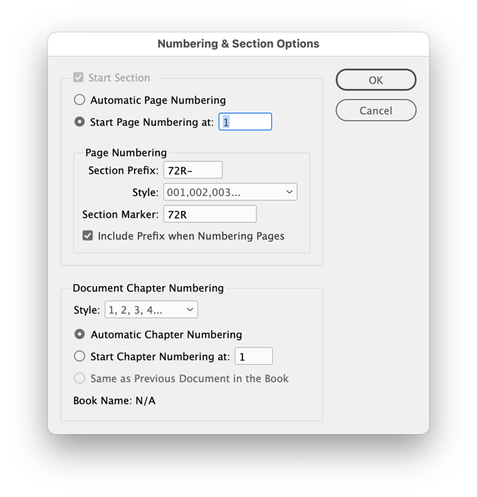

One piece of programming I’d suggest keeping is the “Save InDesign as EPS LineDecals” Applescript. This is designed to export both a version with bleed and trim lines for printing, and a version without bleed for placing inside flag artwork. It saves them both in the correct folders ( “PubInfSys - Documents/actium/flagart/Decals/export” and “PubInfSys - Documents/actium/flagart/Decals/export_bleed” ). These can be changed in the script, although note that AppleScript is old and still uses Classic Macintosh OS path terminology (“Volume:folder:folder:file”).[^2]

# Flag Artwork

There’s nothing all that special about the flag artwork, which is located in “/PubInfSys - Documents/Flags/Flag Artwork”, other than all the elements have a “Script Label” to allow my scripts to create flags automatically and also allow the “Save InDesign As EPS ask.app” script to save the file correctly, adding the stop ID and either “Ft” or “Bk” to the filename. It’s definitely possible to manually lay out flags rather than using the scripts to do it; for one or two flags, it’s easier.

The flags have bleed built in to the document, and trim lines are included. So no bleed is necessary when exporting flags.

# Tools for making flags and decals

Years ago I wrote documentation for how to use the flag tools to make flags. This is in the Github repository as doc/Customized_Flags.md . As far as I know this would all still work if we had an up to date stop-decals.txt. As it is, the main piece that’s useful is the very last section, “Save InDesign As EPS ask.app.”

# Broadway Shuttle

Broadway Shuttle used to have their own flags, which had a lot of information including a schematic map. Just before the pandemic, there was an agreement with the stakeholder group to remove these, and replace them with a double-height (8.25 x 10.25) Broadway Shuttle decal on the regular AC Transit flags. The idea was to incorporate a map and other information in the pole schedule cases, which would then not have specific times (since the service is frequent).

This wasn’t accomplished before the pandemic hit and the service was shut down. What did happen is that the flags (and pole schedule cases) were removed. If the service is resumed, those flag decals need to be put on the AC Transit flags, and presumably, pole schedule cases installed with Broadway Shuttle information.

[^1]: The flagspecs program had a loop that went through the list of stops for each pattern, starting at the end and going backwards. If it saw that a stop had the “BART” or “Amtrak” or whatever box checked, it would add the appropriate icon to all subsequent stops as it found them.
[^2]: Party like it’s 1999!